# Multiple linear regression

*22 July 2020*

by **[Linda N.](http://knlng.github.io)**

## Overview

In contrast to simple linear regression, where there is only one independent variable $x$ and one dependent variable $y$, in multiple linear regression, there are at least two independent variables which results in a two-dimensional array with at least two columns, while $y$ is usually a one-dimensional array.

## Linear regression

Given are a dependent variable $y$ and three influential variables (independent variables) $x_1 , x_2 , x_3$. The linear regression function is

$$y = a + b_1 x_1 + b_2 x_2 + b_3 x_3$$

or equivalent $$y = \vec{b} \cdot \vec{x}$$ where $$\vec{b} = (a, b_1 , b_2 , b_3 )$$ $$\vec{x} = (1, x_1, x_2, x_3)$$

The objective is to make a prediction and hence to calculate the parameters $a, b_1 , b_2$ and $b_3$.

## Example

An example of the given values is listed in the following table.

| $x_1$ | $x_2$ | $x_3$ | $y$ |
| --- | --- | --- | --- |
| 156 | 62 | 24 | 47 |
| 158 | 42 | 34 | 46 |
| 160 | 83 | 26 | 46 |
| 179 | 69 | 51 | 53 |
| 156 | 74 | 43 | 47 |

The three variables are vectors and can be written in the matrix $X$

$$X = \begin{pmatrix} 1 & 156 & 62 & 24 \\ 1 & 158 & 42 & 34 \\ 1 & 160 & 83 & 26 \\ 1 & 179 & 69 & 51 \\ 1 & 156 & 74 & 43 \end{pmatrix}$$

as well as the vector of the dependent variable $y$

$$\vec{y} = \begin{pmatrix} 47 \\ 46 \\ 46 \\ 53 \\ 47 \end{pmatrix}.$$

With the help of matrix $X$ and vector $\vec{y}$, it is possible to estimate the vector $\vec{b}$ of the parameters:

$$\vec{b} = \begin{pmatrix} a \\ b_1 \\ b_2 \\ b_3 \end{pmatrix} = (X^T * X)^{-1} * X^T * \vec{y}$$

The result will give the regression function as mentioned above:

$$y = a + b_1 x_1 + b_2 x_2 + b_3 x_3$$

## Meaning of the parameters

- values $< 0 \rightarrow$ negative effect
- values $> 0 \rightarrow$ positive effect

If the value of an independent variable is very small, it is possible that this variable does not have an influence on the dependent variable. The p-value allows the estimation whether the independent variable has a significant effect or not.

- if the p-value is $< 0.05 \rightarrow$ independent variable has a significant effect
- if the p-value is $> 0.05 \rightarrow$ independent variable does not have significant effect

## Execution with Python

### Linear regression stepwise

First, import the required package `numpy`. Provide the known inputs $x_1, x_2, x_3$ and the output $y$. Print them to see how they look like.

```python
import numpy as np

x = [
    [156, 62, 24],
    [158, 42, 34],
    [160, 83, 26],
    [179, 69, 51],
    [156, 74, 43]]
y = [47, 46, 46, 53, 47]

x, y = np.array(x), np.array(y)

print(x)
print(y)
```

```
[[156  62  24]
 [158  42  34]
 [160  83  26]
 [179  69  51]
 [156  74  43]]
[47 46 46 53 47]
```

Create a variable for each column and print them.

```python
x_1 = x[:,0]
x_2 = x[:,1]
x_3 = x[:,2]

print(x_1)
print(x_2)
print(x_3)
```

```
[156 158 160 179 156]
[62 42 83 69 74]
[24 34 26 51 43]
```

Build the sample matrix $X$. The number of samples in this example is $N = 5$ and the number of columns is 4 as there are $1, x_1, x_2, x_3$. Print the sample matrix $X$.

```python
N = 5
X = np.zeros((N, 4))

X[:, 0] = 1
X[:, 1] = x_1
X[:, 2] = x_2
X[:, 3] = x_3

print(X)
```

```
[[  1. 156.  62.  24.]
 [  1. 158.  42.  34.]
 [  1. 160.  83.  26.]
 [  1. 179.  69.  51.]
 [  1. 156.  74.  43.]]
```

Build and print the transposed matrix $X^T$.

```python
X_T = X.T
print(X.T)
```

```
[[  1.   1.   1.   1.   1.]
 [156. 158. 160. 179. 156.]
 [ 62.  42.  83.  69.  74.]
 [ 24.  34.  26.  51.  43.]]
```

Build and print the reshaped $y$.

```python
y_reshaped = y.reshape(N,1)
print(y_reshaped)
```

```
[[47]
 [46]
 [46]
 [53]
 [47]]
```

Check the shape of built dimensions:

```python
print(X.shape)
print(X_T.shape)
print(y_reshaped.shape)
```

```
(5, 4)
(4, 5)
(5, 1)
```

Finally, compute linear regression with formula.

```python
b = np.linalg.inv(X_T.dot(X)).dot(X_T).dot(y_reshaped)

print(b)
```

```
[[6.79567394e+00]
 [2.40553503e-01]
 [2.22481730e-03]
 [5.43800938e-02]]
```

### Using Python package `sklearn`

First, import the required packages `numpy` and `LinearRegression` from `sklearn.linear_model`. Create a list for the matrix $X$ and one for $\vec{y}$. Print the y-intercept and the coefficients.

```python
import numpy as np
from sklearn.linear_model import LinearRegression
X = np.array([
    [156, 62, 24],
    [158, 42, 34],
    [160, 83, 26],
    [179, 69, 51],
    [156, 74, 43]])
y = np.array([47, 46, 46, 53, 47])
reg = LinearRegression().fit(X, y)

print(reg.intercept_)
print(reg.coef_)
```

```
6.795673938828877
[0.2405535  0.00222482 0.05438009]
```

Create a list with the whole result and overwrite it into a column vector.

```python
b_sklearn = np.array([reg.intercept_,
                      reg.coef_[0],
                      reg.coef_[1],
                      reg.coef_[2]])
b_sklearn = b_sklearn.reshape(4, 1)
print(b_sklearn)
```

```
[[6.79567394e+00]
 [2.40553503e-01]
 [2.22481730e-03]
 [5.43800938e-02]]
```

### Compare the two methods for equality:

```python
# compare the stepwise method with the sklearn method
np.max( np.abs( b-b_sklearn ))
```

```
5.5067062021407764e-12
```

As the value is very small, both results can be considered to be numerically equal.

### Plot the result with `matplotlib`

As it is only possible to plot maximal three-dimensional diagrams, a new example is shown in the following table.

| $x_1$ | $x_2$ | $y$ |
| --- | --- | --- |
| 156 | 62 | 47 |
| 158 | 42 | 46 |
| 160 | 83 | 46 |
| 179 | 69 | 53 |
| 156 | 74 | 47 |

```python
import numpy as np
from sklearn.linear_model import LinearRegression

# create a list with the values
X = np.array([[156, 62], [158, 42], [160, 83], [179, 69], [156, 74]])
y = np.array([47, 46, 46, 53, 47])

# use LinearRegression from sklearn.linear_model
reg = LinearRegression().fit(X, y)

# calculate interception and coefficients
print(f"interception: {reg.intercept_}")
print(f"coefficients: {reg.coef_}")
```

```
interception: 1.5843722264213866
coefficients: [ 0.28582162 -0.00045925]
```

With this result it is possible to plot the data. Import `matplotlib.pyplot` and `Axes3D` from `mpl_toolkits.mplot3d`.

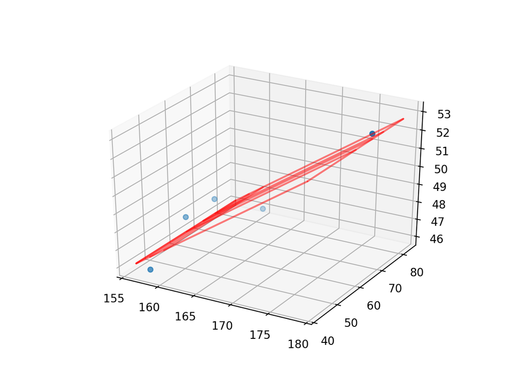

```python
# import the required packages
import matplotlib.pyplot as plt
from mpl_toolkits.mplot3d import Axes3D

# required to make the 3D plot interactive
%matplotlib notebook

# built the frame
fig = plt.figure()
ax = fig.add_subplot(111, projection='3d')

# scatter plots
ax.scatter(X[:, 0], X[:, 1], y)

# create a linear regression plane with command meshgrid
X_1, X_2 = np.meshgrid(x_1, x_2)
Y = reg.intercept_ + reg.coef_[0] * X_1 + reg.coef_[1] * X_2
ax.plot_wireframe(X_1, X_2, Y, color='red', alpha=0.5)

plt.show()
```

## References

- Linear Regression in Python. 20 Jul 2020 https://realpython.com/linear-regression-in-python/
- sklearn.linear_model.LinearRegression. 20 Jul 2020 https://scikit-learn.org/stable/modules/generated/sklearn.linear_model.LinearRegression.html
- Linear Regression Example. 20 Jul 2020 https://scikit-learn.org/stable/auto_examples/linear_model/plot_ols.html
- 3d_regression_example. 20 Jul 2020 https://gist.github.com/aricooperdavis/c658fc1c5d9bdc5b50ec94602328073b